# **Travail Pratique - Analyse des Ventes d'un Magasin**

### **Informations Générales**

- **Nom de l'étudiant**: Akpo Akisch
- **Parcours**: Licence 3 Développement d'Application
- **Université**: UCAO (Université Catholique d'Afrique de l'Ouest)
- **UE**: Programmation Python
- **Professeur**: Mr LOUKOUME
- **Année académique**: 2024/2025
- **Nombre de crédits**: 3

### **Objectif du TP**

Ce travail pratique a pour objectif d'analyser les ventes d'un magasin à partir de données transactionnelles, en utilisant des outils de gestion de bases de données (SQLite) et de traitement des données (Pandas). Le TP consiste en la création de visualisations graphiques afin de mieux comprendre les tendances et comportements dans les ventes.

### **Résumé**

Le TP comporte plusieurs étapes essentielles qui incluent :

# 📊Étape 1 : Modélisation de la Base de Données

## Schéma Entité-Association (E/A)

## Entités

### Produits

- `id`: Identifiant unique du produit
- `nom`: Nom du produit
- `categorie_id`: Référence à la catégorie du produit
- `prix_unitaire`: Prix unitaire du produit

### Categories

- `id`: Identifiant unique de la catégorie
- `nom`: Nom de la catégorie

### Clients

- `id`: Identifiant unique du client
- `nom`: Nom du client
- `email`: Email du client
- `téléphone`: Numéro de téléphone du client

### Ventes

- `id`: Identifiant unique de la vente
- `produit_id`: Référence au produit vendu
- `client_id`: Référence au client ayant effectué l'achat
- `employe_id`: Référence à l'employé qui a réalisé la vente
- `date`: Date de la vente
- `quantite`: Quantité de produit vendu
- `montant`: Montant total de la vente

### Paiements

- `id`: Identifiant unique du paiement
- `vente_id`: Référence à la vente associée
- `mode_paiement`: Mode de paiement utilisé
- `statut`: Statut du paiement (par exemple, "complété", "en attente", etc.)
- `date_paiement`: Date du paiement

### Employes

- `id`: Identifiant unique de l'employé
- `nom`: Nom de l'employé
- `poste`: Poste de l'employé dans l'entreprise
- `email`: Email de l'employé
- `téléphone`: Numéro de téléphone de l'employé

## Relations

1. **Produits - Categories** : Un produit appartient à une catégorie.
2. **Ventes - Produits** : Une vente contient un produit spécifique.
3. **Ventes - Clients** : Une vente est effectuée par un client.
4. **Ventes - Employes** : Une vente est réalisée par un employé.
5. **Paiements - Ventes** : Un paiement est associé à une vente spécifique.

## Conclusion

Ce modèle relationnel permet d'assurer l'intégrité des données et de faciliter l'analyse des ventes. La prochaine étape consistera à créer la base de données et insérer des données d'exemple.

# Étape 2 : Création de la base de données et insertion des données simulées

## 2.1 Création des tables

Les tables ont été créées pour modéliser les catégories, produits, clients, employés, ventes et paiements. La structure de la base de données respecte le modèle fourni dans le document précédent.

```python
import sqlite3

conn = sqlite3.connect('ventes_magasin.db')
cursor = conn.cursor()

cursor.execute('''
CREATE TABLE IF NOT EXISTS Categories (
    id INTEGER PRIMARY KEY AUTOINCREMENT,
    nom TEXT NOT NULL UNIQUE
);
''')

cursor.execute('''
CREATE TABLE IF NOT EXISTS Produits (
    id INTEGER PRIMARY KEY AUTOINCREMENT,
    nom TEXT NOT NULL,
    categorie_id INTEGER,
    prix_unitaire REAL NOT NULL CHECK (prix_unitaire > 0),
    FOREIGN KEY (categorie_id) REFERENCES Categories (id) ON DELETE SET NULL
);
''')

cursor.execute('''
CREATE TABLE IF NOT EXISTS Clients (
    id INTEGER PRIMARY KEY AUTOINCREMENT,
    nom TEXT NOT NULL,
    email TEXT CHECK (email LIKE '%@%.%' OR email IS NULL),
    telephone TEXT
);
''')

cursor.execute('''
CREATE TABLE IF NOT EXISTS Employes (
    id INTEGER PRIMARY KEY AUTOINCREMENT,
    nom TEXT NOT NULL,
    poste TEXT NOT NULL,
    email TEXT CHECK (email LIKE '%@%.%' OR email IS NULL),
    telephone TEXT
);
''')

cursor.execute('''
CREATE TABLE IF NOT EXISTS Ventes (
    id INTEGER PRIMARY KEY AUTOINCREMENT,
    produit_id INTEGER NOT NULL,
    client_id INTEGER NOT NULL,
    employe_id INTEGER,
    date TEXT NOT NULL CHECK (date LIKE '____-__-__'),
    quantite INTEGER NOT NULL CHECK (quantite > 0),
    montant REAL NOT NULL CHECK (montant >= 0),
    FOREIGN KEY (produit_id) REFERENCES Produits (id) ON DELETE RESTRICT,
    FOREIGN KEY (client_id) REFERENCES Clients (id) ON DELETE RESTRICT,
    FOREIGN KEY (employe_id) REFERENCES Employes (id) ON DELETE SET NULL
);
''')

cursor.execute('''
CREATE TABLE IF NOT EXISTS Paiements (
    id INTEGER PRIMARY KEY AUTOINCREMENT,
    vente_id INTEGER NOT NULL,
    mode_paiement TEXT NOT NULL CHECK (mode_paiement IN ('Carte', 'Espèces', 'Virement')),
    statut TEXT NOT NULL CHECK (statut IN ('Complété', 'En attente', 'Échoué')),
    date_paiement TEXT CHECK (date_paiement LIKE '____-__-__' OR date_paiement IS NULL),
    FOREIGN KEY (vente_id) REFERENCES Ventes (id) ON DELETE CASCADE
);
''')

conn.commit()
conn.close()
```

## 2.2 Insertion de données

Nous avons inséré les données suivantes dans la base de données :

### Détails des ventes :

```python
import sqlite3
import random
from faker import Faker
from datetime import datetime, timedelta

fake = Faker('fr_FR')  # Version française pour des données réalistes

def generer_donnees():
    conn = sqlite3.connect('ventes_magasin.db')
    cursor = conn.cursor()

    categories = ['Électronique', 'Vêtements', 'Meubles', 'Jouets', 'Alimentation']
    cursor.executemany("INSERT INTO Categories (nom) VALUES (?)", [(c,) for c in categories])

    produits = [
        ('Telephone', 1, 79900.99),
        ('Ordinateur portable', 1, 129900.99),
        ('Habit', 2, 1900.99),
        ('Pantalon', 2, 4900.99),
        ('Tableau', 3, 59900.99),
        ('Monopoli', 4, 1400.99),
        ('Chocolat', 5, 400.99)
    ]
    cursor.executemany("INSERT INTO Produits (nom, categorie_id, prix_unitaire) VALUES (?, ?, ?)", produits)

    clients = [(fake.name(), fake.email(), fake.phone_number()) for _ in range(10)]
    cursor.executemany("INSERT INTO Clients (nom, email, telephone) VALUES (?, ?, ?)", clients)

    postes = ['Vendeur', 'Valideur', 'Caissier', 'Responsable', 'Gérant']
    employes = [(fake.name(), postes[i], f"employe{i}@magasin.com", fake.phone_number()) for i in range(5)]
    cursor.executemany("INSERT INTO Employes (nom, poste, email, telephone) VALUES (?, ?, ?, ?)", employes)

    # Ventes (100 ventes sur 6 mois)
    start_date = datetime.now() - timedelta(days=180)
    for _ in range(100):
        produit_id = random.randint(1, len(produits))
        client_id = random.randint(1, 10)
        employe_id = random.randint(1, 5)
        quantite = random.randint(1, 5)

        cursor.execute("SELECT prix_unitaire FROM Produits WHERE id = ?", (produit_id,))
        prix_unitaire = cursor.fetchone()[0]
        montant = round(quantite * prix_unitaire, 2)

        # Date aléatoire sur 6 mois
        jours_aleatoires = random.randint(0, 180)
        date_vente = (start_date + timedelta(days=jours_aleatoires)).strftime('%Y-%m-%d')

        cursor.execute("""
            INSERT INTO Ventes (produit_id, client_id, employe_id, date, quantite, montant)
            VALUES (?, ?, ?, ?, ?, ?)
        """, (produit_id, client_id, employe_id, date_vente, quantite, montant))

    #génération des paiements
    modes_paiement = ['Carte', 'Espèces', 'Virement']
    statuts_possibles = ['Complété', 'En attente', 'Échoué']

    for vente_id in range(1, 101):
        mode = random.choice(modes_paiement)
        statut = random.choices(statuts_possibles, weights=[0.8, 0.15, 0.05])[0]  # 80% Complété, 15% En attente, 5% Échoué

        cursor.execute("SELECT date FROM Ventes WHERE id = ?", (vente_id,))
        date_vente = datetime.strptime(cursor.fetchone()[0], '%Y-%m-%d')

        # Ajout cohérent de la date de paiement
        if statut == 'Complété':
            jours_retard = random.randint(0, 3)
        else:
            jours_retard = random.randint(1, 7)  # Retard plus long si non complété

        date_paiement = (date_vente + timedelta(days=jours_retard)).strftime('%Y-%m-%d')

        cursor.execute("""
            INSERT INTO Paiements (vente_id, mode_paiement, statut, date_paiement)
            VALUES (?, ?, ?, ?)
        """, (vente_id, mode, statut, date_paiement))

    conn.commit()
    conn.close()
    print("Données générées avec succès!")

if __name__ == '__main__':
    generer_donnees()
```

```
Données générées avec succès!
```

### 2.3 Vérification des données

Une fois les données insérées, des requêtes ont été effectuées pour vérifier l'intégrité des informations dans chaque table de la base de données.

```python
import sqlite3

conn = sqlite3.connect('ventes_magasin.db')
cursor = conn.cursor()

# Vérification des donnéés

cursor.execute('SELECT * FROM Categories;')
print("\n=== CATÉGORIES ===")
print("(ID, Nom)")
for row in cursor.fetchall():
    print(row)

cursor.execute('SELECT * FROM Produits;')
print("\n=== PRODUITS ===")
print("(ID, Nom, Catégorie_ID, Prix)")
for row in cursor.fetchall():
    print(row)

cursor.execute('SELECT * FROM Clients;')
print("\n=== CLIENTS ===")
print("(ID, Nom, Email, Téléphone)")
for row in cursor.fetchall():
    print(row)

cursor.execute('SELECT * FROM Employes;')
print("\n=== EMPLOYÉS ===")
print("(ID, Nom, Poste, Email, Téléphone)")
for row in cursor.fetchall():
    print(row)

cursor.execute('SELECT * FROM Ventes;')
print("\n=== VENTES ===")
print("(ID, Produit_ID, Client_ID, Employé_ID, Date, Quantité, Montant)")
for row in cursor.fetchall():
    print(row)

cursor.execute('SELECT * FROM Paiements;')
print("\n=== PAIEMENTS ===")
print("(ID, Vente_ID, Mode, Statut, Date_Paiement)")
for row in cursor.fetchall():
    print(row)

conn.close()
print("\nVérification terminée!")
```

```
=== CATÉGORIES ===
(ID, Nom)
(1, 'Électronique')
(2, 'Vêtements')
(3, 'Meubles')
(4, 'Jouets')
(5, 'Alimentation')

=== PRODUITS ===
(ID, Nom, Catégorie_ID, Prix)
(1, 'Telephone', 1, 79900.99)
(2, 'Ordinateur portable', 1, 129900.99)
(3, 'Habit', 2, 1900.99)
(4, 'Pantalon', 2, 4900.99)
(5, 'Tableau', 3, 59900.99)
(6, 'Monopoli', 4, 1400.99)
(7, 'Chocolat', 5, 400.99)

=== CLIENTS ===
(ID, Nom, Email, Téléphone)
(1, 'Théodore de la Joseph', 'letellierdominique@example.org', '+33 (0)3 55 66 78 94')
(2, 'Élise-Michelle Adam', 'jschmitt@example.org', '+33 (0)6 32 20 06 20')
(3, 'Virginie Lucas', 'aurore75@example.org', '+33 (0)2 28 60 50 89')
(4, 'Sylvie Guillaume', 'nicolasstephanie@example.com', '01 56 17 16 10')
(5, 'Alix Legrand', 'augeranne@example.net', '02 31 92 17 44')
(6, 'Olivie-Anaïs Normand', 'blancalexandre@example.net', '0586471651')
(7, 'Noël Maillet', 'pichonhelene@example.org', '+33 5 96 48 58 69')
(8, 'Emmanuelle-Dominique Gaudin', 'astridbarre@example.net', '0477536581')
(9, 'Jérôme Muller', 'penelopelefevre@example.com', '01 48 96 05 82')
(10, 'Henriette Laine', 'helenemartins@example.net', '+33 4 57 97 13 88')

=== EMPLOYÉS ===
(ID, Nom, Poste, Email, Téléphone)
(1, 'Marcel Tessier', 'Vendeur', 'employe0@magasin.com', '0471060989')
(2, 'Philippine Joseph', 'Valideur', 'employe1@magasin.com', '0388389484')
(3, 'Éric Pierre', 'Caissier', 'employe2@magasin.com', '+33 (0)4 93 96 83 34')
(4, 'Monique Delmas de la Bouvier', 'Responsable', 'employe3@magasin.com', '+33 4 85 00 61 59')
(5, 'Charles-Auguste Courtois', 'Gérant', 'employe4@magasin.com', '0143923165')

=== VENTES ===
```

[output cut: 191 more lines]

```
(88, 88, 'Virement', 'En attente', '2024-12-29')
(89, 89, 'Espèces', 'Complété', '2024-11-25')
(90, 90, 'Virement', 'Complété', '2024-10-12')
(91, 91, 'Espèces', 'Complété', '2025-01-30')
(92, 92, 'Virement', 'Complété', '2024-10-17')
(93, 93, 'Carte', 'En attente', '2025-02-10')
(94, 94, 'Espèces', 'Complété', '2025-01-12')
(95, 95, 'Espèces', 'Complété', '2024-11-09')
(96, 96, 'Virement', 'Échoué', '2024-11-16')
(97, 97, 'Espèces', 'Complété', '2025-02-24')
(98, 98, 'Carte', 'Complété', '2024-10-19')
(99, 99, 'Virement', 'Complété', '2025-02-08')
(100, 100, 'Espèces', 'Complété', '2025-01-25')

Vérification terminée!
```

## Étape 3 : Extraction des données avec Python (avec Pandas)

### Objectif

L'objectif de cette étape est de charger les données de la base SQLite dans Python en utilisant **Pandas** et de les manipuler facilement dans des DataFrames pour les étapes suivantes du projet.

### 1. Connexion à la base de données SQLite

Nous nous connectons à la base de données `ventes_magasin.db` en utilisant le module `sqlite3` de Python.

```python
import sqlite3
import pandas as pd

conn = sqlite3.connect('ventes_magasin.db')
```

### 2. Extraction des données avec Pandas

Nous chargeons les données des tables dans des DataFrames Pandas à l aide de 'pd.read_sql_query()'.

```python
categories_df = pd.read_sql_query("SELECT * FROM Categories;", conn)
produits_df = pd.read_sql_query("SELECT * FROM Produits;", conn)
clients_df = pd.read_sql_query("SELECT * FROM Clients;", conn)
employes_df = pd.read_sql_query("SELECT * FROM Employes;", conn)
ventes_df = pd.read_sql_query("SELECT * FROM Ventes;", conn)
paiements_df = pd.read_sql_query("SELECT * FROM Paiements;", conn)
```

### 3. Jointure des tables pour obtenir des informations utiles

Nous joignons les tables Ventes, Produits, et Clients pour obtenir un tableau combiné avec les informations sur chaque vente ('produit', 'client', 'date', 'quantité', 'montant').

```python
# Jointure entre les ventes avec les produits et les clients
ventes_clients_produits_df = pd.read_sql_query("""
    SELECT V.id AS vente_id,
           P.nom AS produit,
           C.nom AS client,
           V.date AS date_vente,
           V.quantite,
           V.montant
    FROM Ventes V
    JOIN Produits P ON V.produit_id = P.id
    JOIN Clients C ON V.client_id = C.id;
""", conn)
#Jointure entre les ventes et les employés
ventes_employes_df = pd.read_sql_query("""
    SELECT V.id AS vente_id,
           P.nom AS produit,
           C.nom AS client,
           E.nom AS employe,
           V.date AS date_vente,
           V.quantite,
           V.montant
    FROM Ventes V
    JOIN Produits P ON V.produit_id = P.id
    JOIN Clients C ON V.client_id = C.id
    JOIN Employes E ON V.employe_id = E.id;
""", conn)
#Jointure entre les ventes et les paiements
ventes_paiements_df = pd.read_sql_query("""
    SELECT V.id AS vente_id,
           P.nom AS produit,
           C.nom AS client,
           V.date AS date_vente,
           V.quantite,
           V.montant,
           Pa.mode_paiement,
           Pa.statut,
           Pa.date_paiement
    FROM Ventes V
    JOIN Produits P ON V.produit_id = P.id
    JOIN Clients C ON V.client_id = C.id
    JOIN Paiements Pa ON V.id = Pa.vente_id;
""", conn)
# Jointure entre les ventes et les catégories de produits
ventes_categories_df = pd.read_sql_query("""
    SELECT V.id AS vente_id,
           P.nom AS produit,
           C.nom AS client,
           V.date AS date_vente,
           V.quantite,
           V.montant,
           Ca.nom AS categorie
    FROM Ventes V
    JOIN Produits P ON V.produit_id = P.id
    JOIN Clients C ON V.client_id = C.id
    JOIN Categories Ca ON P.categorie_id = Ca.id;
""", conn)
# Jointure entre toutes les tables pour obtenir une vue complète
ventes_completes_df = pd.read_sql_query("""
    SELECT V.id AS vente_id,
           P.nom AS produit,
           C.nom AS client,
           V.date AS date_vente,
           V.quantite,
           V.montant,
           E.nom AS employe,
           Pa.mode_paiement,  -- Mode de paiement
           Pa.statut,         -- Statut du paiement
           Cat.nom AS categorie
    FROM Ventes V
    JOIN Produits P ON V.produit_id = P.id
    JOIN Clients C ON V.client_id = C.id
    JOIN Employes E ON V.employe_id = E.id
    JOIN Paiements Pa ON V.id = Pa.vente_id
    JOIN Categories Cat ON P.categorie_id = Cat.id;
""", conn)
ventes_jointures = pd.read_sql_query("""
    SELECT
        V.id AS vente_id,
        V.date AS date_vente,
        P.nom AS produit,
        P.prix_unitaire,
        V.quantite,
        V.montant,
        C.nom AS client,
        E.nom AS employe,
        Pa.mode_paiement,
        Pa.statut,
        Pa.date_paiement,
        Cat.nom AS categorie
    FROM Ventes V
    JOIN Produits P ON V.produit_id = P.id
    JOIN Clients C ON V.client_id = C.id
    LEFT JOIN Employes E ON V.employe_id = E.id
    LEFT JOIN Paiements Pa ON V.id = Pa.vente_id
    JOIN Categories Cat ON P.categorie_id = Cat.id
""", conn)
```

### 4. Vérification des données extraites

Nous affichons les 5 premières lignes de chaque DataFrame pour vérifier que les données ont été correctement extraites. La méthode head() de Pandas permet d afficher un échantillon des données et de confirmer qu elles sont bien importées.

```python
print("=== TABLES DE BASE ===")
print("\nCatégories :\n", categories_df.head())
print("\nProduits :\n", produits_df.head())
print("\nClients :\n", clients_df.head())
print("\nEmployés :\n", employes_df.head())
print("\nVentes :\n", ventes_df.head())
print("\nPaiements :\n", paiements_df.head())
```

```
=== TABLES DE BASE ===

Catégories :
    id           nom
0   1  Électronique
1   2     Vêtements
2   3       Meubles
3   4        Jouets
4   5  Alimentation

Produits :
    id                  nom  categorie_id  prix_unitaire
0   1            Telephone             1       79900.99
1   2  Ordinateur portable             1      129900.99
2   3                Habit             2        1900.99
3   4             Pantalon             2        4900.99
4   5              Tableau             3       59900.99

Clients :
    id                    nom                           email  \
0   1  Théodore de la Joseph  letellierdominique@example.org
1   2    Élise-Michelle Adam            jschmitt@example.org
2   3         Virginie Lucas            aurore75@example.org
3   4       Sylvie Guillaume    nicolasstephanie@example.com
4   5           Alix Legrand           augeranne@example.net

              telephone
0  +33 (0)3 55 66 78 94
1  +33 (0)6 32 20 06 20
2  +33 (0)2 28 60 50 89
3        01 56 17 16 10
4        02 31 92 17 44

Employés :
    id                           nom        poste                 email  \
0   1                Marcel Tessier      Vendeur  employe0@magasin.com
1   2             Philippine Joseph     Valideur  employe1@magasin.com
2   3                   Éric Pierre     Caissier  employe2@magasin.com
3   4  Monique Delmas de la Bouvier  Responsable  employe3@magasin.com
4   5      Charles-Auguste Courtois       Gérant  employe4@magasin.com
```

[output cut: 8 more lines]

```
Ventes :
    id  produit_id  client_id  employe_id        date  quantite    montant
0   1           4          3           3  2024-11-24         5   24504.95
1   2           2         10           3  2025-01-24         3  389702.97
2   3           1          8           3  2024-12-19         2  159801.98
3   4           1          5           5  2024-12-09         3  239702.97
4   5           1          8           4  2025-01-11         3  239702.97

Paiements :
    id  vente_id mode_paiement      statut date_paiement
0   1         1      Virement    Complété    2024-11-26
1   2         2       Espèces    Complété    2025-01-24
2   3         3         Carte    Complété    2024-12-21
3   4         4         Carte  En attente    2024-12-14
4   5         5      Virement    Complété    2025-01-12
```

### 5. Fermeture de la connexion à la base de données

Après avoir extrait les données, nous fermons la connexion à la base de données.

```python
conn.close()
```

Conclusion Les données ont été extraites et vérifiées avec succès. Elles sont maintenant prêtes à être manipulées et analysées dans les étapes suivantes.

## Étape 4 : Analyse statistique avec Pandas et NumPy

### Objectif

L'objectif de cette étape est d'effectuer une analyse exploratoire et statistique sur les données de ventes du magasin. Nous allons utiliser **Pandas** pour manipuler les données et **NumPy** pour les calculs numériques. Les analyses incluront le chiffre d'affaires total, les produits les plus vendus, l'analyse par client, ainsi que d'autres statistiques descriptives.

### 1. Préparation des données

Avant de commencer les analyses, nous devons nous assurer que les données sont bien préparées, notamment les dates des ventes qui seront utilisées pour les groupements mensuels et journaliers.

```python
import pandas as pd
import numpy as np
```

# Convertir la colonne 'date' en type datetime

```python
ventes_df['date'] = pd.to_datetime(ventes_df['date'])
```

# Extraire l'année et le mois pour les groupements mensuels

```python
ventes_df['annee_mois'] = ventes_df['date'].dt.to_period('M')
ventes_df['jour'] = ventes_df['date'].dt.date
```

### 2. Chiffre d'affaires total

Nous calculons le chiffre d’affaires total sur la période couverte par les données en sommant tous les montants des ventes.

```python
ca_total = ventes_df['montant'].sum()
print(f"Chiffre d'affaires total : {ca_total}")
```

```
Chiffre d'affaires total : 10791178.190000001
```

### 3. Chiffre d'affaires moyen par mois et par jour

Nous allons calculer le chiffre d'affaires moyen par mois et par jour. Cela nous permettra d'identifier les périodes avec des ventes plus fortes ou plus faibles.

Chiffre d'affaires moyen par mois :

```python
ca_moyen_mois = ventes_df.groupby('annee_mois')['montant'].mean()
print("Chiffre d'affaires moyen par mois:")
print(ca_moyen_mois)
```

```
Chiffre d'affaires moyen par mois:
annee_mois
2024-10     84908.024737
2024-11    111533.168000
2024-12    133102.657368
2025-01    186895.685714
2025-02     57722.772000
2025-03     72765.976364
2025-04     67752.475000
Freq: M, Name: montant, dtype: float64
```

Chiffre d'affaires moyen par jour :

```python
ca_moyen_jour = ventes_df.groupby('jour')['montant'].mean()
print("Chiffre d'affaires moyen par jour:")
print(ca_moyen_jour)
```

```
Chiffre d'affaires moyen par jour:
jour
2024-10-06      801.980000
2024-10-10     9801.980000
2024-10-11     3801.980000
2024-10-12    10735.973333
2024-10-13     2801.980000
                  ...
2025-03-15      400.990000
2025-03-17     4900.990000
2025-03-18    59900.990000
2025-03-21     1603.960000
2025-04-04    67752.475000
Name: montant, Length: 69, dtype: float64
```

### 4. Produits les plus vendus

Pour déterminer les produits les plus populaires, nous allons grouper les ventes par produit et trier par quantité ou montant des ventes.

Produits les plus vendus par quantité

```python
produits_par_quantite = ventes_completes_df.groupby('produit')['quantite'].sum().sort_values(ascending=False)
top_3_produits_quantite = produits_par_quantite.head(3)
print("Top 3 des produits par quantité vendue:")
print(top_3_produits_quantite)
```

```
Top 3 des produits par quantité vendue:
produit
Telephone    54
Pantalon     49
Monopoli     45
Name: quantite, dtype: int64
```

```python
ventes_completes_df['ca_par_produit'] = ventes_completes_df['quantite'] * ventes_completes_df['montant']
produits_par_ca = ventes_completes_df.groupby('produit')['ca_par_produit'].sum().sort_values(ascending=False)
top_3_produits_ca = produits_par_ca.head(3)
print("Top 3 des produits par chiffre d'affaires:")
print(top_3_produits_ca)
```

```
Top 3 des produits par chiffre d'affaires:
produit
Ordinateur portable    15068514.84
Telephone              13423366.32
Tableau                 6349504.94
Name: ca_par_produit, dtype: float64
```

### 5. Analyse par client

Nous pouvons analyser les clients les plus rentables en fonction du chiffre d’affaires total généré par chaque client ou calculer le panier moyen par client.

Chiffre d'affaires total par client

```python
ca_par_client = ventes_completes_df.groupby('client')['montant'].sum().sort_values(ascending=False)
top_3_clients = ca_par_client.head(3)
print("Top 3 des clients par chiffre d'affaires généré:")
print(top_3_clients)
```

```
Top 3 des clients par chiffre d'affaires généré:
client
Élise-Michelle Adam    2277237.62
Sylvie Guillaume       1534435.64
Alix Legrand           1298524.75
Name: montant, dtype: float64
```

Nombre moyen de transactions par client

```python
transactions_par_client = ventes_completes_df.groupby('client')['vente_id'].count().mean()
print(f"Nombre moyen de transactions par client : {transactions_par_client}")
```

```
Nombre moyen de transactions par client : 10.0
```

### 6. Statistiques descriptives générales

Nous allons maintenant obtenir des statistiques descriptives sur les montants des ventes. Cela inclut des informations comme la vente maximale, la vente minimale, et l'écart-type des montants de vente.

```python
# Statistiques descriptives des montants de vente
print("Statistiques descriptives des montants de vente:")
print(ventes_completes_df['montant'].describe())

max_vente = ventes_completes_df['montant'].max()
print(f"Le plus gros montant pour une vente est : {max_vente}")

min_vente = ventes_completes_df['montant'].min()
print(f"Le plus petit montant pour une vente est : {min_vente}")

ecart_type_ventes = ventes_completes_df['montant'].std()
print(f"L'écart-type des montants de vente est : {ecart_type_ventes}")
```

```
Statistiques descriptives des montants de vente:
count       100.000000
mean     107911.781900
std      150787.380082
min         400.990000
25%        3801.980000
50%       14702.970000
75%      239603.960000
max      649504.950000
Name: montant, dtype: float64
Le plus gros montant pour une vente est : 649504.95
Le plus petit montant pour une vente est : 400.99
L'écart-type des montants de vente est : 150787.38008222915
```

```python
conn.close()
```

## Étape 5 : Visualisation des données avec Matplotlib et Seaborn

### 1. Évolution temporelle des ventes (Chiffre d'affaires)

### Objectif :

Tracer l’évolution du chiffre d'affaires au fil du temps pour identifier des tendances, des pics et des périodes plus calmes.

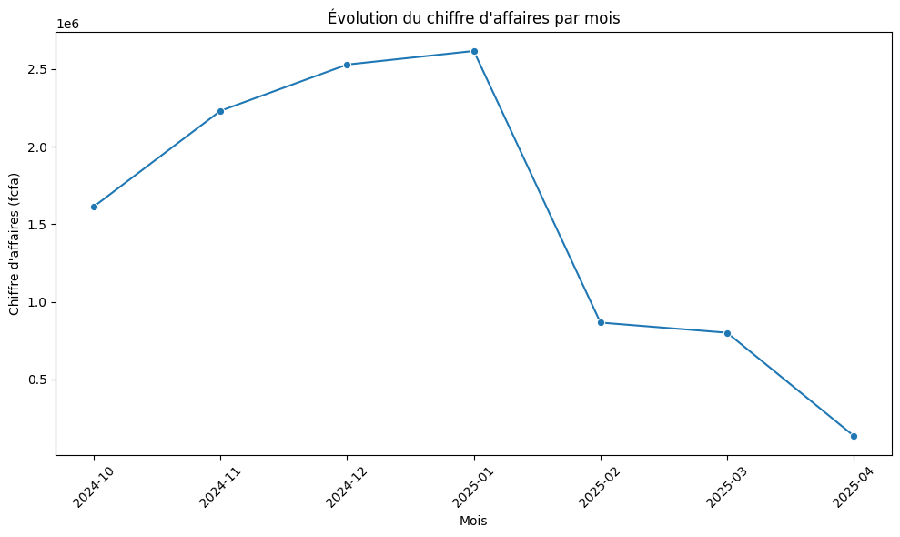

```python
import pandas as pd
import seaborn as sns
import matplotlib.pyplot as plt
import sqlite3

conn = sqlite3.connect('ventes_magasin.db')

# Requête SQL pour obtenir les ventes avec la date et le montant
ventes_df = pd.read_sql_query("""
    SELECT V.date, V.montant
    FROM Ventes V;
""", conn)

ventes_df['date'] = pd.to_datetime(ventes_df['date'])

ventes_df['mois'] = ventes_df['date'].dt.to_period('M')

ventes_df['mois'] = ventes_df['mois'].astype(str)

ventes_par_mois = ventes_df.groupby('mois')['montant'].sum().reset_index()

# Visualisation avec Seaborn
plt.figure(figsize=(10, 6))
sns.lineplot(data=ventes_par_mois, x='mois', y='montant', marker='o')
plt.title("Évolution du chiffre d'affaires par mois")
plt.xlabel("Mois")
plt.ylabel("Chiffre d'affaires (fcfa)")
plt.xticks(rotation=45)
plt.tight_layout()
plt.show()
```

### 2. Répartition des ventes par produit

### Objectif :

Afficher la contribution de chaque produit au chiffre d’affaires global pour identifier les produits les plus rentables.

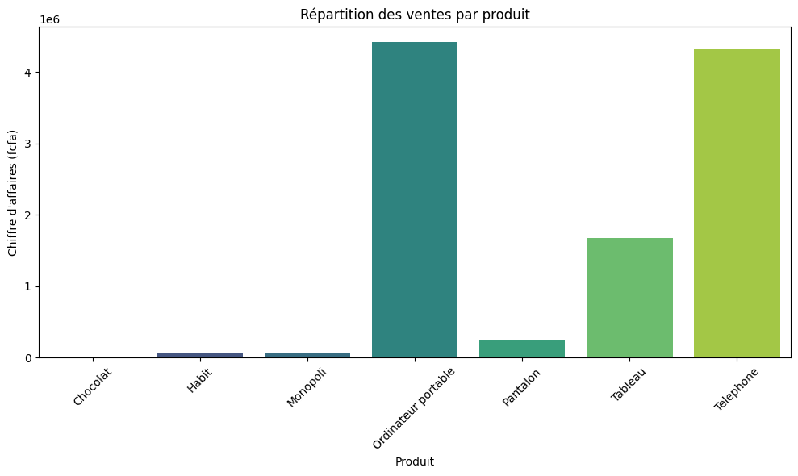

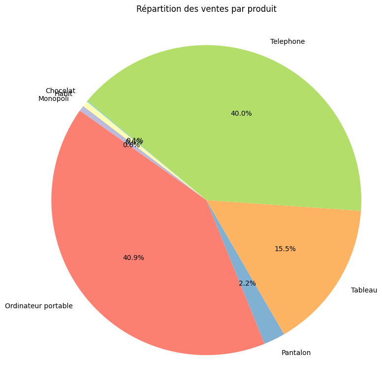

```python
# Requête SQL pour obtenir les ventes par produit
ventes_produits_df = pd.read_sql_query("""
    SELECT P.nom AS produit, SUM(V.montant) AS chiffre_affaires
    FROM Ventes V
    JOIN Produits P ON V.produit_id = P.id
    GROUP BY P.nom;
""", conn)

# Visualisation avec Seaborn (Bar Plot)
plt.figure(figsize=(10, 6))
sns.barplot(data=ventes_produits_df, x='produit', y='chiffre_affaires', palette='viridis', hue='produit', legend='auto')
plt.title("Répartition des ventes par produit")
plt.xlabel("Produit")
plt.ylabel("Chiffre d'affaires (fcfa)")
plt.xticks(rotation=45)
plt.tight_layout()
plt.show()

#Diagramme en secteurs
plt.figure(figsize=(8, 8))
plt.pie(ventes_produits_df['chiffre_affaires'], labels=ventes_produits_df['produit'], autopct='%1.1f%%', startangle=140, colors=sns.color_palette("Set3", len(ventes_produits_df)))
plt.title("Répartition des ventes par produit")
plt.axis('equal')
plt.tight_layout()
plt.show()
```

### Répartition des ventes par produit

Ce graphique montre la répartition des ventes par produit. Nous pouvons observer quel produit génère la majeure partie du chiffre d'affaires. Par exemple, un produit peut représenter une grande part du revenu, tandis qu'un autre peut contribuer de manière marginale. Cette information est essentielle pour la gestion des stocks et la planification des ventes.

### 3. Répartition des ventes par catégorie

### Objectif :

Afficher la contribution de chaque catégorie de produit au chiffre d’affaires total.

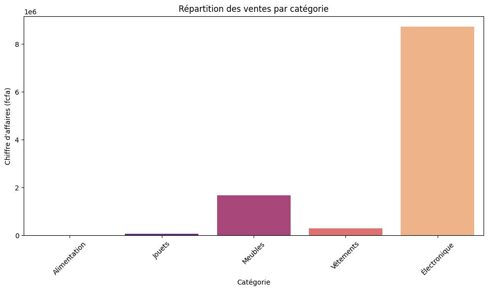

```python
# Requête SQL pour obtenir les ventes par catégorie
ventes_categories_df = pd.read_sql_query("""
    SELECT Cat.nom AS categorie, SUM(V.montant) AS chiffre_affaires
    FROM Ventes V
    JOIN Produits P ON V.produit_id = P.id
    JOIN Categories Cat ON P.categorie_id = Cat.id
    GROUP BY Cat.nom;
""", conn)

# Visualisation avec Seaborn (Bar Plot)
plt.figure(figsize=(10, 6))
sns.barplot(data=ventes_categories_df, x='categorie', y='chiffre_affaires', palette='magma', hue='categorie', legend='auto')
plt.title("Répartition des ventes par catégorie")
plt.xlabel("Catégorie")
plt.ylabel("Chiffre d'affaires (fcfa)")
plt.xticks(rotation=45)
plt.tight_layout()
plt.show()
```

### Répartition des ventes par catégorie

Ce graphique illustre la répartition des ventes selon les catégories de produits. Les catégories ayant une forte contribution au chiffre d'affaires peuvent nécessiter une attention particulière pour l'approvisionnement, la promotion et la gestion des stocks.

### 4. Top clients par montant dépensé

### Objectif :

Afficher quels clients ont dépensé le plus d'argent pour aider à cibler les clients fidèles ou à comprendre les comportements d'achat.

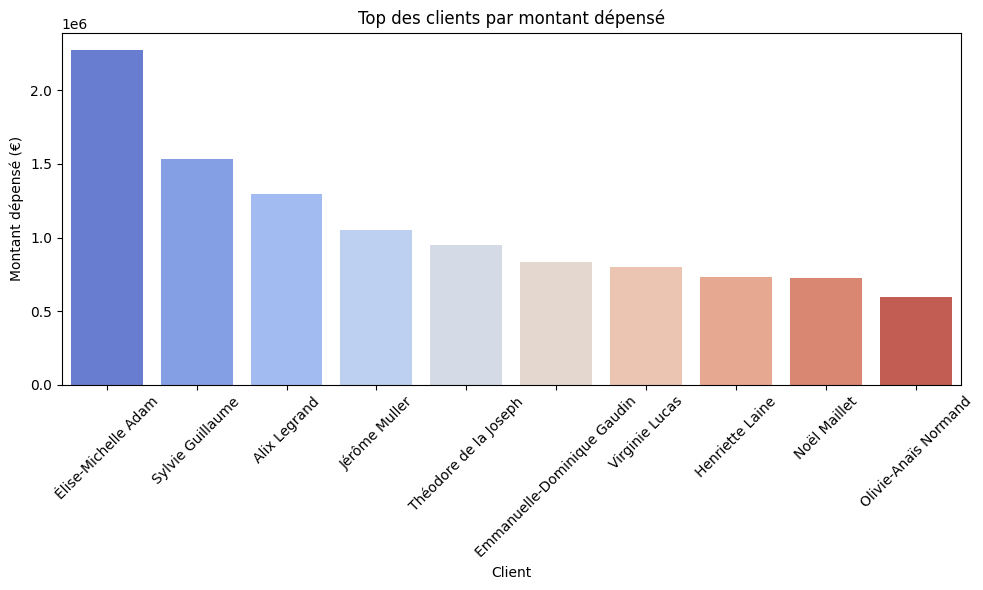

```python
# Requête SQL pour obtenir les clients et leur montant total dépensé
top_clients_df = pd.read_sql_query("""
    SELECT C.nom AS client, SUM(V.montant) AS total_depense
    FROM Ventes V
    JOIN Clients C ON V.client_id = C.id
    GROUP BY C.nom
    ORDER BY total_depense DESC
    LIMIT 10;
""", conn)

# Visualisation avec Seaborn (Bar Plot)
plt.figure(figsize=(10, 6))
sns.barplot(data=top_clients_df, x='client', y='total_depense', palette='coolwarm', hue='client', legend='auto')
plt.title("Top des clients par montant dépensé")
plt.xlabel("Client")
plt.ylabel("Montant dépensé (€)")
plt.xticks(rotation=45)
plt.tight_layout()
plt.show()
```

### 5. Ventes par employé

### Objectif :

Analyser la performance des employés en termes de chiffre d'affaires généré.

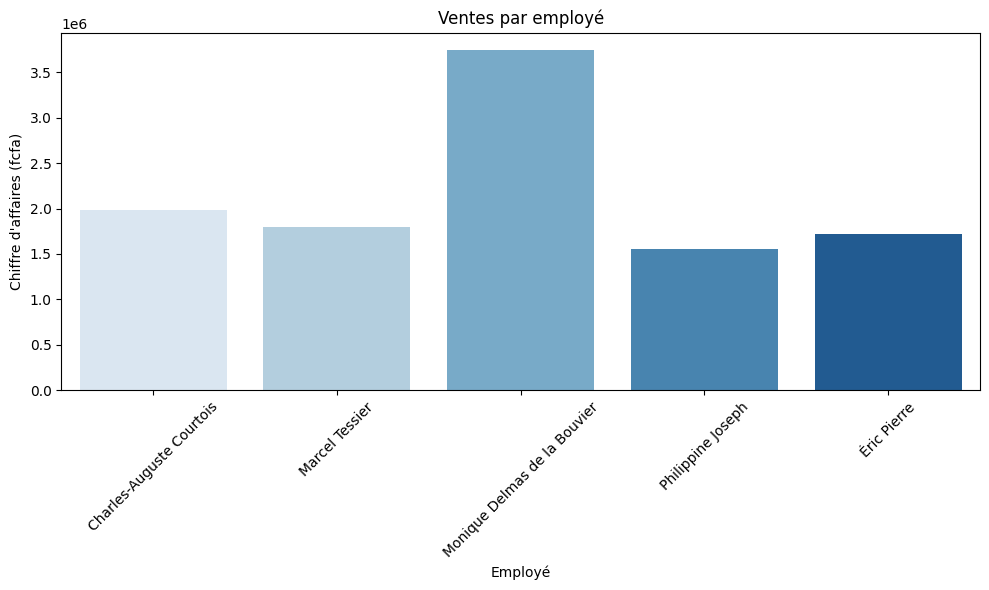

```python
# Requête SQL pour obtenir les ventes par employé
ventes_employes_df = pd.read_sql_query("""
    SELECT E.nom AS employe, SUM(V.montant) AS chiffre_affaires
    FROM Ventes V
    JOIN Employes E ON V.employe_id = E.id
    GROUP BY E.nom;
""", conn)

# Visualisation avec Seaborn (Bar Plot)
plt.figure(figsize=(10, 6))
sns.barplot(data=ventes_employes_df, x='employe', y='chiffre_affaires', palette='Blues', hue='employe', legend='auto')
plt.title("Ventes par employé")
plt.xlabel("Employé")
plt.ylabel("Chiffre d'affaires (fcfa)")
plt.xticks(rotation=45)
plt.tight_layout()
plt.show()
```

### Ventes par employé

Ce graphique présente les ventes totales réalisées par chaque employé. Cela peut être utile pour évaluer la performance des équipes de vente et identifier ceux qui génèrent le plus de chiffre d'affaires. Il peut aussi permettre de repérer des opportunités de formation pour améliorer les performances de certains employés.

## Analyse des Séries Temporelles (Prévision des Ventes)

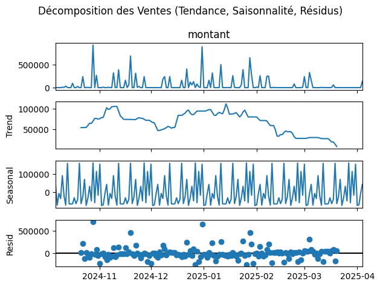

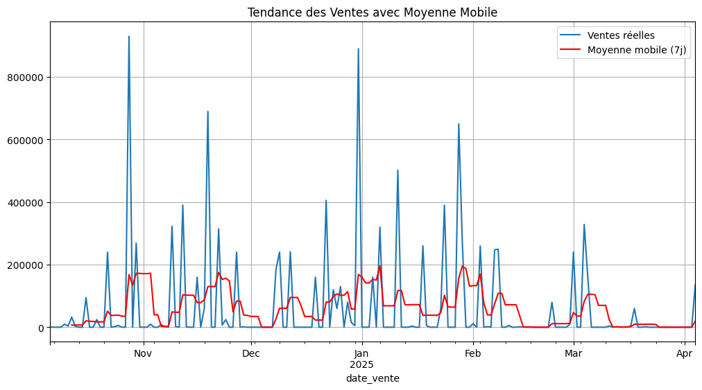

```python
import matplotlib.pyplot as plt
from statsmodels.tsa.seasonal import seasonal_decompose

# Conversion en série temporelle
ventes_jointures['date_vente'] = pd.to_datetime(ventes_jointures['date_vente'])
ventes_ts = ventes_jointures.set_index('date_vente')['montant'].resample('D').sum().fillna(0)

# Découpage saisonnier
result = seasonal_decompose(ventes_ts, model='additive', period=30)

# Visualisation
plt.figure(figsize=(12,8))
result.plot()
plt.suptitle('Décomposition des Ventes (Tendance, Saisonnalité, Résidus)')
plt.tight_layout()
plt.savefig('analyse_saisonniere.png')  # Pour le rapport
plt.show()

# Prévision simple avec moyenne mobile
window_size = 7  # 1 semaine
ventes_ts_rolling = ventes_ts.rolling(window=window_size).mean()

plt.figure(figsize=(12,6))
ventes_ts.plot(label='Ventes réelles')
ventes_ts_rolling.plot(label=f'Moyenne mobile ({window_size}j)', color='red')
plt.title('Tendance des Ventes avec Moyenne Mobile')
plt.legend()
plt.grid(True)
plt.savefig('prevision_ventes.png')
plt.show()
```

### Dashboard Interactif avec Plotly

```python
import plotly.express as px
import plotly.graph_objects as go
from plotly.subplots import make_subplots

# 1. Sunburst des ventes
fig_sunburst = px.sunburst(
    ventes_jointures,
    path=['categorie', 'produit'],
    values='montant',
    title='Répartition du Chiffre d\'Affaires',
    width=800,
    height=600
)
fig_sunburst.write_html("sunburst.html")

# 2. Graphique temporel interactif
ventes_quotidiennes = ventes_jointures.groupby('date_vente')['montant'].sum().reset_index()

fig_temporel = px.line(
    ventes_quotidiennes,
    x='date_vente',
    y='montant',
    title='Évolution Quotidienne des Ventes',
    labels={'montant': 'Chiffre d\'affaires (€)', 'date_vente': 'Date'},
    template='plotly_white'
)
fig_temporel.add_scatter(
    x=ventes_quotidiennes['date_vente'],
    y=ventes_quotidiennes['montant'].rolling(7).mean(),
    name='Moyenne mobile (7j)'
)
fig_temporel.write_html("evolution_ventes.html")

# 3. Dashboard combiné
dashboard = make_subplots(
    rows=2, cols=2,
    specs=[
        [{"type": "sunburst", "rowspan": 2}, {"type": "bar"}],
        [None, {"type": "scatter"}]
    ],
    subplot_titles=("Répartition par Catégorie", "Top 10 Produits", "Tendance des Ventes")
)

# Sunburst
dashboard.add_trace(
    go.Sunburst(
        labels=ventes_jointures['categorie'] + " - " + ventes_jointures['produit'],
        parents=ventes_jointures['categorie'],
        values=ventes_jointures['montant'],
        branchvalues="total"
    ),
    row=1, col=1
)

# Top produits
top_produits = ventes_jointures.groupby('produit')['montant'].sum().nlargest(10)
dashboard.add_trace(
    go.Bar(
        x=top_produits.index,
        y=top_produits.values,
        name="CA par produit"
    ),
    row=1, col=2
)

# Courbe temporelle
dashboard.add_trace(
    go.Scatter(
        x=ventes_quotidiennes['date_vente'],
        y=ventes_quotidiennes['montant'],
        name="Ventes quotidiennes"
    ),
    row=2, col=2
)

dashboard.update_layout(
    height=800,
    width=1200,
    title_text="Dashboard Analytique des Ventes",
    showlegend=True
)
dashboard.write_html("dashboard_complet.html")
conn.close()
```

# **Conclusion Générale**

Ce travail pratique a permis de mettre en œuvre une analyse complète des ventes d'un magasin. À travers différentes étapes, nous avons pu extraire, manipuler et visualiser des données relatives aux transactions. Voici les points clés que nous avons abordés et les résultats obtenus :

1. **Exploration des données** : Nous avons collecté les données depuis une base SQLite et effectué une exploration approfondie, en identifiant les tendances clés, telles que les produits les plus vendus et les pics de ventes.
2. **Jointures entre tables** : Grâce à l'utilisation des jointures SQL, nous avons pu relier les différentes tables de la base de données (produits, ventes, clients, etc.), permettant ainsi une vue d'ensemble complète des transactions du magasin.
3. **Visualisation des tendances** : À travers des graphiques réalisés avec Matplotlib et Seaborn, nous avons visualisé l'évolution du chiffre d'affaires par mois et la répartition des ventes par produit. Ces visualisations ont permis de mettre en évidence des tendances intéressantes, comme les périodes de forte demande et les produits les plus rentables.
4. **Analyse des résultats** : Les graphiques ont permis de dégager des enseignements importants pour le management du magasin, comme l’identification des produits phares à promouvoir davantage ou des périodes où les ventes sont particulièrement élevées.

**En résumé**, ce TP nous a permis de maîtriser plusieurs outils importants pour l'analyse des données, notamment les bases de données relationnelles, les techniques de jointures SQL, et la visualisation des données. Ces compétences sont essentielles pour tout projet de gestion de données dans un environnement commercial ou d'analyse. Cette expérience constitue un pas significatif vers l'intégration de l'analyse de données dans les processus décisionnels d'une entreprise.